# Structured grouped analysis

Let’s try grouping the structural variables within the groups suggested by Philip.

```r
# for replication purposes
set.seed(107)
source('~/ncr_notebooks/baseline_prediction//src/aux_functions.R')
# Philip pre-selected which structural scans to use
gf_fname = '~/data/baseline_prediction/structural_match_02092017.csv'
data_fname = '~/data/baseline_prediction/structural_long_02092017.csv'
gf = read.csv(gf_fname)
group_var = 'DX2'
data = read.csv(data_fname)
maskid_gf = unique(gf[, c('MASKID', group_var)])
ldata = merge(maskid_gf, data, by.x='MASKID', by.y='lh.aparc.thickness', all.y = F)
eval(parse(text=sprintf('groups = ldata$\"%s\"', group_var)))
idx = groups=='NV' | groups=='ADHD'
groups = factor(groups[idx])
ldata = ldata[idx,]
```

Let’s create the sublobar variables first:

```r
regional = read.csv('~/data/baseline_prediction/REGIONAL_ANALYSES_FREESURFER.csv')
sublobar_regions = unique(regional$subloar)
# for each region, add or average the columns corresponding to the ROIs
area_data = c()
hdr = c()
volume_data = c()
thickness_data = c()
aparc_data = c()
aparc_hdr = c()
for (s in sublobar_regions) {
  if (s != "") {
    idx = which(regional$subloar == s)
    area = 0
    volume = 0
    thickness = 0
    aparc = 0
    for (i in idx) {
      cnt = 0
      roi_name = sub('_thickness', '', regional[i, 1])
      if (length(grep('rh_|lh_', roi_name)) > 0) {
        var_name = quote(sprintf('%s_area', roi_name))
        area = area + ldata[, eval(var_name)]
        var_name = quote(sprintf('%s_volume', roi_name))
        volume = volume + ldata[, eval(var_name)]
        var_name = quote(sprintf('%s_thickness', roi_name))
        thickness = thickness + ldata[, eval(var_name)]
        cnt = cnt + 1
      }
      else {
        var_name = quote(roi_name)
        aparc = aparc + ldata[, eval(var_name)]
      }
    }
    if (sum(area) > 0) {
      hdr = c(hdr, s)
      area_data = cbind(area_data, area)
      volume_data = cbind(volume_data, volume)
      thickness_data = cbind(thickness_data, thickness / cnt)
    }
    else {
      aparc_hdr = c(aparc_hdr, s)
      aparc_data = cbind(aparc_data, aparc)
    }
  }
}
colnames(area_data) = hdr
colnames(volume_data) = hdr
colnames(thickness_data) = hdr
colnames(aparc_data) = aparc_hdr
# hdr = c()
# for (s in sublobar_regions) {
#   if (s != "") {
#     if (length(grep('rh_|lh_', s)) == 1) {
#       for (i in c('area', 'volume', 'thickness')) {
#         hdr = c(hdr, sprintf('%s_%s', s, i))
#       }
#     }
#     else {
#         hdr = c(hdr, s)
#     }
#   }
# }
# sublobar = data.frame(matrix(ncol=length(hdr), nrow=0))
# colnames(sublobar) <- hdr
```

And we do the same thing for lobar:

```r
regional = read.csv('~/data/baseline_prediction/REGIONAL_ANALYSES_FREESURFER.csv')
lobar_regions = unique(regional$lobar)
# for each region, add or average the columns corresponding to the ROIs
areaLobar_data = c()
hdr = c()
volumeLobar_data = c()
thicknessLobar_data = c()
aparcLobar_data = c()
aparc_hdr = c()
for (s in lobar_regions) {
  if (s != "") {
    idx = which(regional$lobar == s)
    area = 0
    volume = 0
    thickness = 0
    aparc = 0
    for (i in idx) {
      cnt = 0
      roi_name = sub('_thickness', '', regional[i, 1])
      if (length(grep('rh_|lh_', roi_name)) > 0) {
        var_name = quote(sprintf('%s_area', roi_name))
        area = area + ldata[, eval(var_name)]
        var_name = quote(sprintf('%s_volume', roi_name))
        volume = volume + ldata[, eval(var_name)]
        var_name = quote(sprintf('%s_thickness', roi_name))
        thickness = thickness + ldata[, eval(var_name)]
        cnt = cnt + 1
      }
      else {
        var_name = quote(roi_name)
        aparc = aparc + ldata[, eval(var_name)]
      }
    }
    if (sum(area) > 0) {
      hdr = c(hdr, s)
      areaLobar_data = cbind(areaLobar_data, area)
      volumeLobar_data = cbind(volumeLobar_data, volume)
      thicknessLobar_data = cbind(thicknessLobar_data, thickness / cnt)
    }
    else {
      aparc_hdr = c(aparc_hdr, s)
      aparcLobar_data = cbind(aparcLobar_data, aparc)
    }
  }
}
colnames(areaLobar_data) = hdr
colnames(volumeLobar_data) = hdr
colnames(thicknessLobar_data) = hdr
colnames(aparcLobar_data) = aparc_hdr
```

And finally, we do it for the theory driven cases:

```r
regional = read.csv('~/data/baseline_prediction/REGIONAL_ANALYSES_FREESURFER.csv')
theory_regions = unique(regional$ROI_theory_driven)
# for each region, add or average the columns corresponding to the ROIs
areaTheory_data = c()
hdr = c()
volumeTheory_data = c()
thicknessTheory_data = c()
aparcTheory_data = c()
aparc_hdr = c()
for (s in theory_regions) {
  if (s != "") {
    idx = which(regional$ROI_theory_driven == s)
    area = 0
    volume = 0
    thickness = 0
    aparc = 0
    for (i in idx) {
      cnt = 0
      roi_name = sub('_thickness', '', regional[i, 1])
      if (length(grep('rh_|lh_', roi_name)) > 0) {
        var_name = quote(sprintf('%s_area', roi_name))
        area = area + ldata[, eval(var_name)]
        var_name = quote(sprintf('%s_volume', roi_name))
        volume = volume + ldata[, eval(var_name)]
        var_name = quote(sprintf('%s_thickness', roi_name))
        thickness = thickness + ldata[, eval(var_name)]
        cnt = cnt + 1
      }
      else {
        var_name = quote(roi_name)
        aparc = aparc + ldata[, eval(var_name)]
      }
    }
    if (sum(area) > 0) {
      hdr = c(hdr, s)
      areaTheory_data = cbind(areaTheory_data, area)
      volumeTheory_data = cbind(volumeTheory_data, volume)
      thicknessTheory_data = cbind(thicknessTheory_data, thickness / cnt)
    }
    else {
      aparc_hdr = c(aparc_hdr, s)
      aparcTheory_data = cbind(aparcTheory_data, aparc)
    }
  }
}
colnames(areaTheory_data) = hdr
colnames(volumeTheory_data) = hdr
colnames(thicknessTheory_data) = hdr
colnames(aparcTheory_data) = aparc_hdr
```

Alright, so now it’s a matter of of checking what works best.

# Area

## sublobar

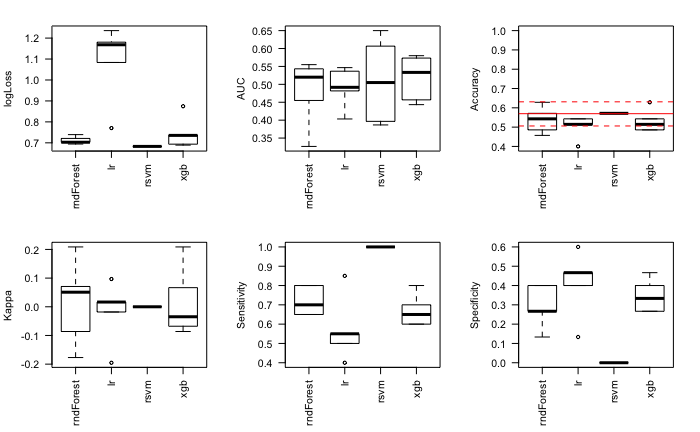

```r
ldata = area_data
root_fname = '~/data/baseline_prediction/results/structSublobarArea_NVvsADHD'
save(ldata, groups, file=sprintf('%s.RData', root_fname), compress=T)
# ... waiting ...
res = collect_results(root_fname)
mylist = res[[1]]
run_models = res[[2]]
source('~/ncr_notebooks/baseline_prediction/src/do_metrics_plots.R')
```

## sublobar - PCA

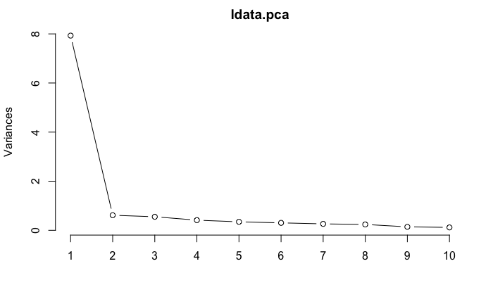

```r
ldata.pca <- prcomp(ldata, center=T, scale=T)
plot(ldata.pca, type = "l")
```

```r
print(ldata.pca$sdev^2)  # these are the eignevalues
```

```
 [1] 7.93018999 0.61524753 0.55140944 0.41447245 0.34544364 0.30374017 0.26234715 0.23931296 0.14145751 0.11803886
[11] 0.07834029
```

There’s not much question that 1 or 2 PCs here are enough. I’ll go with 2.

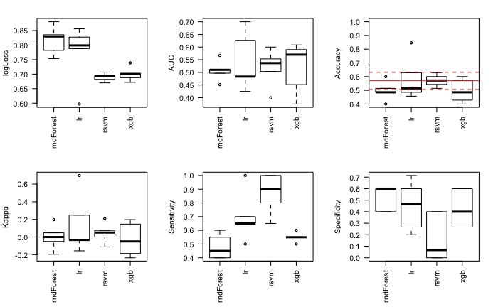

```r
ldata = ldata.pca$x[, 1:2]
root_fname = '~/data/baseline_prediction/results/structSublobarArea_PCAElbow_NVvsADHD'
save(ldata, groups, file=sprintf('%s.RData', root_fname), compress=T)
# ... waiting ...
res = collect_results(root_fname)
mylist = res[[1]]
run_models = res[[2]]
source('~/ncr_notebooks/baseline_prediction/src/do_metrics_plots.R')
```

## lobar

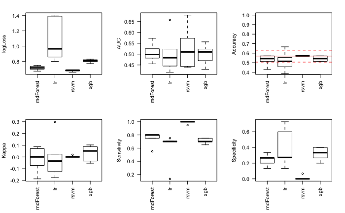

```r
ldata = areaLobar_data
root_fname = '~/data/baseline_prediction/results/structLobarArea_NVvsADHD'
save(ldata, groups, file=sprintf('%s.RData', root_fname), compress=T)
# ... waiting ...
res = collect_results(root_fname)
mylist = res[[1]]
run_models = res[[2]]
source('~/ncr_notebooks/baseline_prediction/src/do_metrics_plots.R')
```

## lobar - PCA

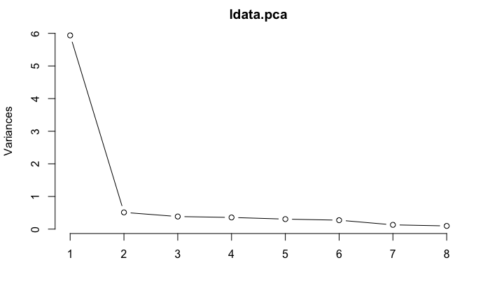

```r
ldata.pca <- prcomp(ldata, center=T, scale=T)
plot(ldata.pca, type = "l")
```

```r
print(ldata.pca$sdev^2)  # these are the eignevalues
```

```
[1] 5.93771374 0.51184517 0.38540610 0.35725863 0.30633367 0.27307189 0.13084129 0.09752951
```

Same as before… just 2 will do it.

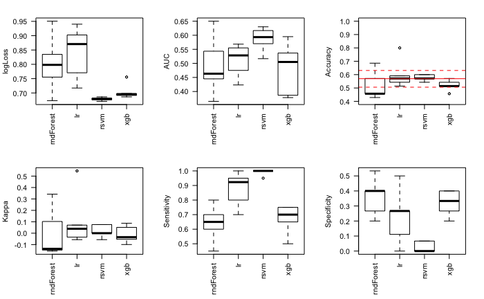

```r
ldata = ldata.pca$x[, 1:2]
root_fname = '~/data/baseline_prediction/results/structLobarArea_PCAElbow_NVvsADHD'
save(ldata, groups, file=sprintf('%s.RData', root_fname), compress=T)
# ... waiting ...
res = collect_results(root_fname)
mylist = res[[1]]
run_models = res[[2]]
source('~/ncr_notebooks/baseline_prediction/src/do_metrics_plots.R')
```

## theory

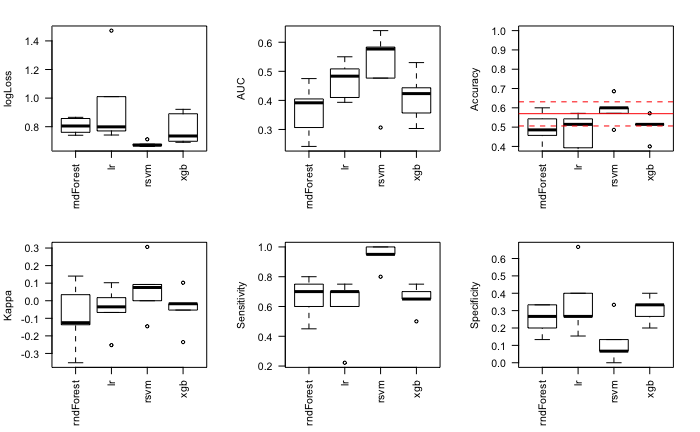

```r
ldata = areaTheory_data
root_fname = '~/data/baseline_prediction/results/structTheoryArea_NVvsADHD'
save(ldata, groups, file=sprintf('%s.RData', root_fname), compress=T)
# ... waiting ...
res = collect_results(root_fname)
mylist = res[[1]]
run_models = res[[2]]
source('~/ncr_notebooks/baseline_prediction/src/do_metrics_plots.R')
```

## theory - PCA

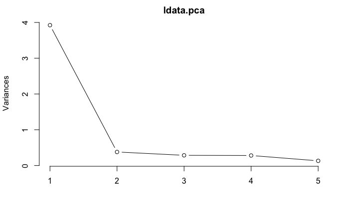

```r
ldata.pca <- prcomp(ldata, center=T, scale=T)
plot(ldata.pca, type = "l")
```

```r
print(ldata.pca$sdev^2)  # these are the eignevalues
```

```
[1] 3.9241286 0.3788654 0.2853746 0.2803855 0.1312459
```

Again, using 2 just so we’re not doing a univariate deal.

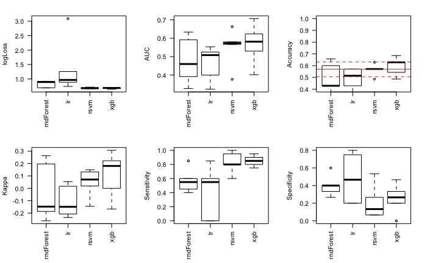

```r
ldata = ldata.pca$x[, 1:2]
root_fname = '~/data/baseline_prediction/results/structTheoryArea_PCAElbow_NVvsADHD'
save(ldata, groups, file=sprintf('%s.RData', root_fname), compress=T)
# ... waiting ...
res = collect_results(root_fname)
mylist = res[[1]]
run_models = res[[2]]
source('~/ncr_notebooks/baseline_prediction/src/do_metrics_plots.R')
```

# Thickness

## sublobar

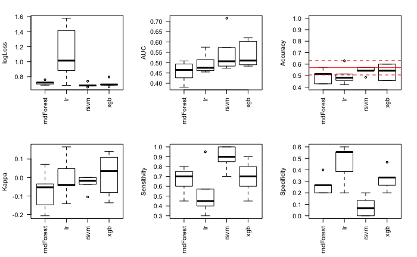

```r
ldata = thickness_data
root_fname = '~/data/baseline_prediction/results/structSublobarThickness_NVvsADHD'
save(ldata, groups, file=sprintf('%s.RData', root_fname), compress=T)
# ... waiting ...
res = collect_results(root_fname)
mylist = res[[1]]
run_models = res[[2]]
source('~/ncr_notebooks/baseline_prediction/src/do_metrics_plots.R')
```

## sublobar - PCA

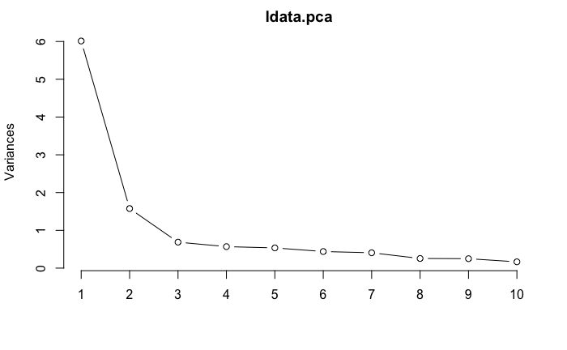

```r
ldata.pca <- prcomp(ldata, center=T, scale=T)
plot(ldata.pca, type = "l")
```

```r
print(ldata.pca$sdev^2)  # these are the eignevalues
```

```
 [1] 6.0137269 1.5771409 0.6876095 0.5683334 0.5353576 0.4391108 0.4062475 0.2552654 0.2494750 0.1663180 0.1014150
```

Here we could go with 2 or 3. I’ll go with 2 because it’s the EV threshold.

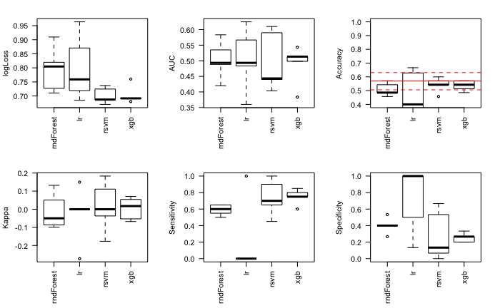

```r
ldata = ldata.pca$x[, 1:2]
root_fname = '~/data/baseline_prediction/results/structSublobarThickness_PCAElbow_NVvsADHD'
save(ldata, groups, file=sprintf('%s.RData', root_fname), compress=T)
# ... waiting ...
res = collect_results(root_fname)
mylist = res[[1]]
run_models = res[[2]]
source('~/ncr_notebooks/baseline_prediction/src/do_metrics_plots.R')
```

## lobar

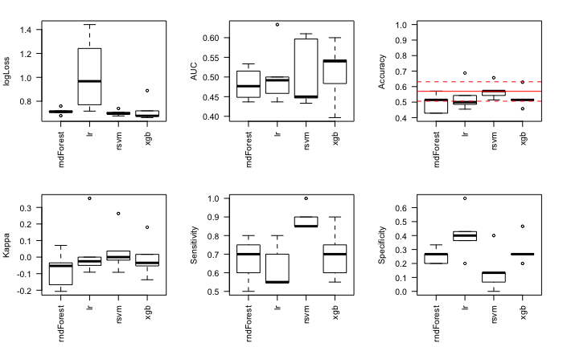

```r
ldata = thicknessLobar_data
root_fname = '~/data/baseline_prediction/results/structLobarThickness_NVvsADHD'
save(ldata, groups, file=sprintf('%s.RData', root_fname), compress=T)
# ... waiting ...
res = collect_results(root_fname)
mylist = res[[1]]
run_models = res[[2]]
source('~/ncr_notebooks/baseline_prediction/src/do_metrics_plots.R')
```

## lobar - PCA

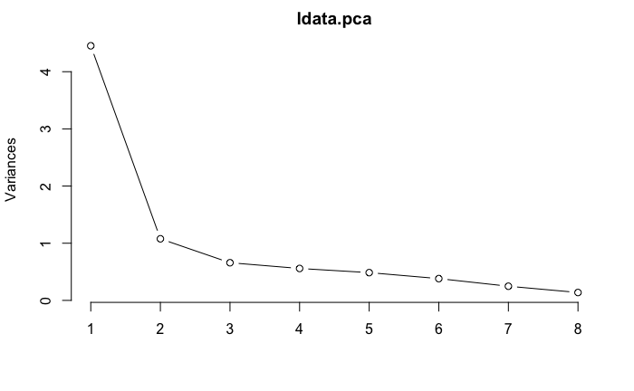

```r
ldata.pca <- prcomp(ldata, center=T, scale=T)
plot(ldata.pca, type = "l")
```

```r
print(ldata.pca$sdev^2)  # these are the eignevalues
```

```
[1] 4.4533299 1.0772035 0.6587600 0.5584220 0.4855883 0.3811682 0.2475927 0.1379354
```

Same as before… just 2 will do it.

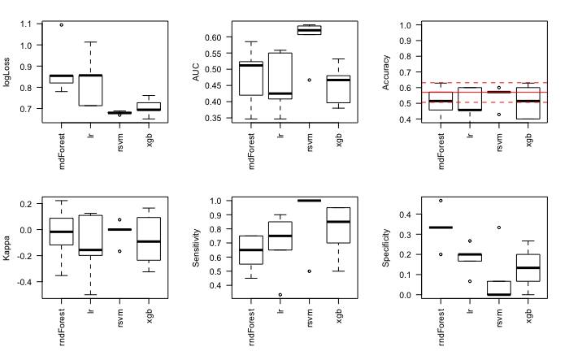

```r
ldata = ldata.pca$x[, 1:2]
root_fname = '~/data/baseline_prediction/results/structLobarThickness_PCAElbow_NVvsADHD'
save(ldata, groups, file=sprintf('%s.RData', root_fname), compress=T)
# ... waiting ...
res = collect_results(root_fname)
mylist = res[[1]]
run_models = res[[2]]
source('~/ncr_notebooks/baseline_prediction/src/do_metrics_plots.R')
```

## theory

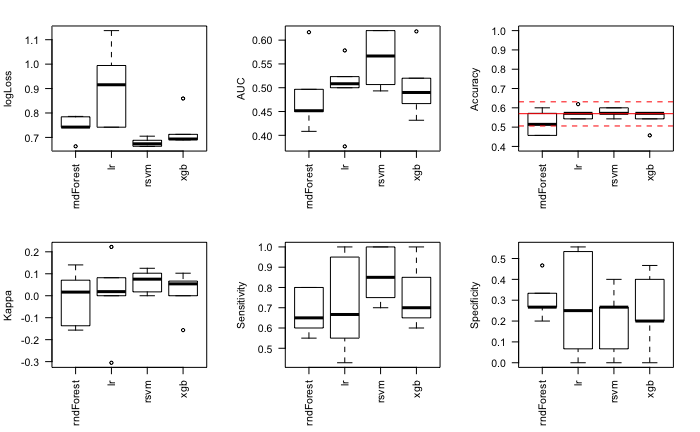

```r
ldata = thicknessTheory_data
root_fname = '~/data/baseline_prediction/results/structTheoryThickness_NVvsADHD'
save(ldata, groups, file=sprintf('%s.RData', root_fname), compress=T)
# ... waiting ...
res = collect_results(root_fname)
mylist = res[[1]]
run_models = res[[2]]
source('~/ncr_notebooks/baseline_prediction/src/do_metrics_plots.R')
```

## theory - PCA

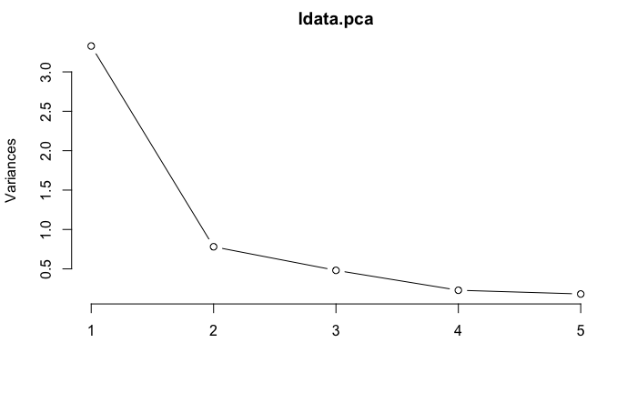

```r
ldata.pca <- prcomp(ldata, center=T, scale=T)
plot(ldata.pca, type = "l")
```

```r
print(ldata.pca$sdev^2)  # these are the eignevalues
```

```
[1] 3.3284725 0.7806646 0.4812564 0.2285540 0.1810526
```

Again, using 2 just so we’re not doing a univariate deal.

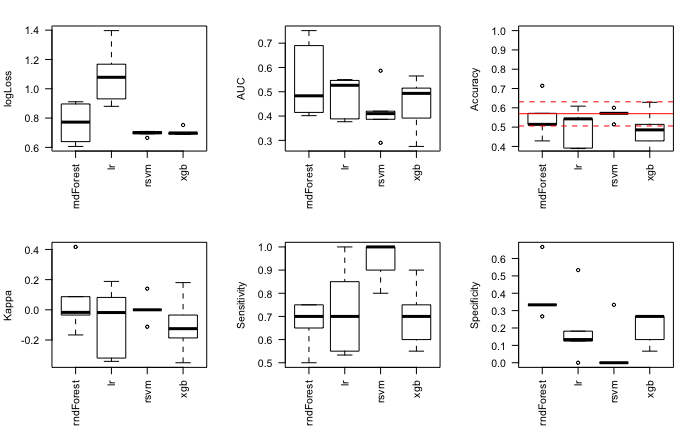

```r
ldata = ldata.pca$x[, 1:2]
root_fname = '~/data/baseline_prediction/results/structTheoryThickness_PCAElbow_NVvsADHD'
save(ldata, groups, file=sprintf('%s.RData', root_fname), compress=T)
# ... waiting ...
res = collect_results(root_fname)
mylist = res[[1]]
run_models = res[[2]]
source('~/ncr_notebooks/baseline_prediction/src/do_metrics_plots.R')
```

# Volume

## sublobar

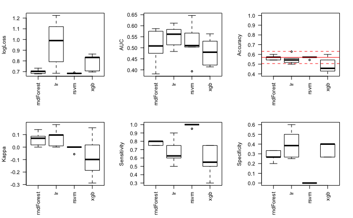

```r
ldata = volume_data
root_fname = '~/data/baseline_prediction/results/structSublobarVolume_NVvsADHD'
save(ldata, groups, file=sprintf('%s.RData', root_fname), compress=T)
# ... waiting ...
res = collect_results(root_fname)
mylist = res[[1]]
run_models = res[[2]]
source('~/ncr_notebooks/baseline_prediction/src/do_metrics_plots.R')
```

## sublobar - PCA

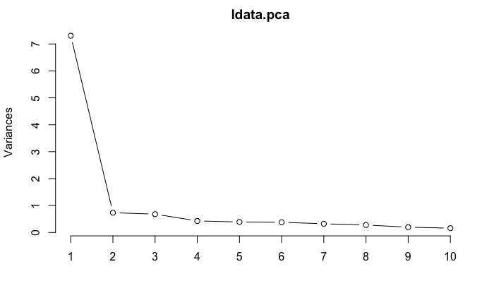

```r
ldata.pca <- prcomp(ldata, center=T, scale=T)
plot(ldata.pca, type = "l")
```

```r
print(ldata.pca$sdev^2)  # these are the eignevalues
```

```
 [1] 7.3071957 0.7344331 0.6803877 0.4287348 0.3900836 0.3792527 0.3222095 0.2770995 0.1969290 0.1595042 0.1241702
```

Same situation as with thickness. I’ll go with 2.

```r
ldata = ldata.pca$x[, 1:2]
root_fname = '~/data/baseline_prediction/results/structSublobarVolume_PCAElbow_NVvsADHD'
save(ldata, groups, file=sprintf('%s.RData', root_fname), compress=T)
# ... waiting ...
res = collect_results(root_fname)
```

```
Error in binom.test(sum(diag(x)), sum(x)) :
  'n' must be a positive integer >= 'x'
```

## lobar

```r
ldata = volumeLobar_data
root_fname = '~/data/baseline_prediction/results/structLobarVolume_NVvsADHD'
save(ldata, groups, file=sprintf('%s.RData', root_fname), compress=T)
# # ... waiting ...
# res = collect_results(root_fname)
# mylist = res[[1]]
# run_models = res[[2]]
# source('~/ncr_notebooks/baseline_prediction/src/do_metrics_plots.R')
```

## lobar - PCA

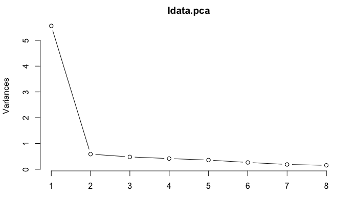

```r
ldata.pca <- prcomp(ldata, center=T, scale=T)
plot(ldata.pca, type = "l")
```

```r
print(ldata.pca$sdev^2)  # these are the eignevalues
```

```
[1] 5.5605930 0.5867453 0.4789245 0.4145984 0.3564623 0.2641717 0.1859780 0.1525267
```

Same as before… just 2 will do it.

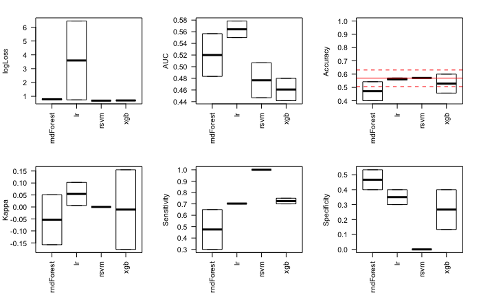

```r
ldata = ldata.pca$x[, 1:2]
root_fname = '~/data/baseline_prediction/results/structLobarVolume_PCAElbow_NVvsADHD'
save(ldata, groups, file=sprintf('%s.RData', root_fname), compress=T)
# ... waiting ...
res = collect_results(root_fname)
mylist = res[[1]]
run_models = res[[2]]
source('~/ncr_notebooks/baseline_prediction/src/do_metrics_plots.R')
```

## theory

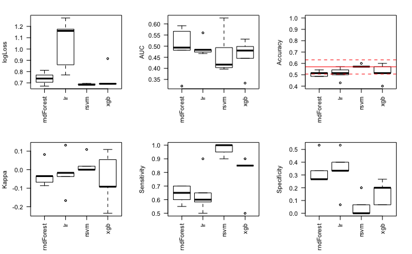

```r
ldata = volumeTheory_data
root_fname = '~/data/baseline_prediction/results/structTheoryVolume_NVvsADHD'
save(ldata, groups, file=sprintf('%s.RData', root_fname), compress=T)
# ... waiting ...
res = collect_results(root_fname)
mylist = res[[1]]
run_models = res[[2]]
source('~/ncr_notebooks/baseline_prediction/src/do_metrics_plots.R')
```

## theory - PCA

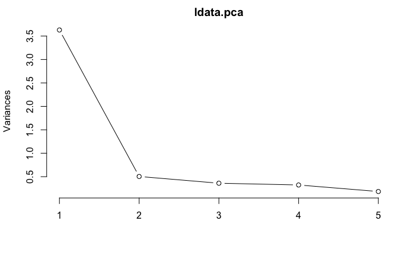

```r
ldata.pca <- prcomp(ldata, center=T, scale=T)
plot(ldata.pca, type = "l")
```

```r
print(ldata.pca$sdev^2)  # these are the eignevalues
```

```
[1] 3.6299062 0.5039237 0.3603345 0.3225841 0.1832515
```

Again, using 2 just so we’re not doing a univariate deal.

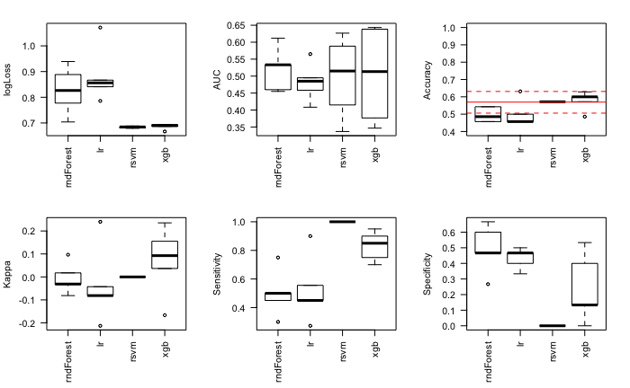

```r
ldata = ldata.pca$x[, 1:2]
root_fname = '~/data/baseline_prediction/results/structTheoryVolume_PCAElbow_NVvsADHD'
save(ldata, groups, file=sprintf('%s.RData', root_fname), compress=T)
# ... waiting ...
res = collect_results(root_fname)
mylist = res[[1]]
run_models = res[[2]]
source('~/ncr_notebooks/baseline_prediction/src/do_metrics_plots.R')
```

# aparc

Let’s see if there’s anything interesting in the aparc segmentation:

## sublobar

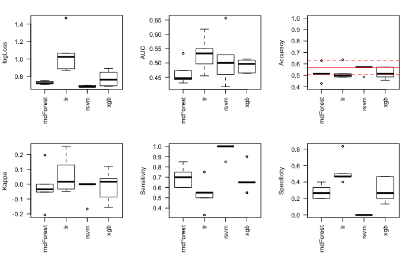

```r
ldata = aparc_data
root_fname = '~/data/baseline_prediction/results/structSublobarAparc_NVvsADHD'
save(ldata, groups, file=sprintf('%s.RData', root_fname), compress=T)
# ... waiting ...
res = collect_results(root_fname)
mylist = res[[1]]
run_models = res[[2]]
source('~/ncr_notebooks/baseline_prediction/src/do_metrics_plots.R')
```

## sublobar, PCA

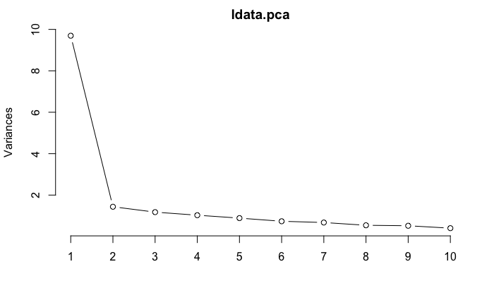

```r
ldata.pca <- prcomp(ldata, center=T, scale=T)
plot(ldata.pca, type = "l")
```

```r
print(ldata.pca$sdev^2)  # these are the eignevalues
```

```
 [1] 9.694678e+00 1.437019e+00 1.176890e+00 1.028442e+00 8.884273e-01 7.360368e-01 6.753191e-01 5.419523e-01
 [9] 5.194673e-01 4.025878e-01 3.344206e-01 2.413018e-01 2.127533e-01 8.725487e-02 1.159658e-02 9.115298e-03
[17] 2.718327e-03 1.891484e-05
```

The usual shpill, 2 PCs will do it.

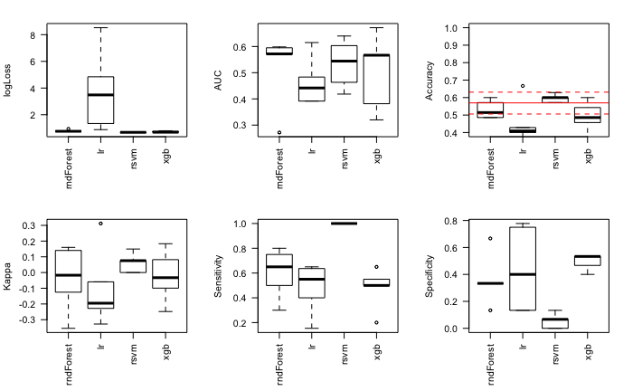

```r
ldata = ldata.pca$x[, 1:2]
root_fname = '~/data/baseline_prediction/results/structSublobarAparc_PCAElbow_NVvsADHD'
save(ldata, groups, file=sprintf('%s.RData', root_fname), compress=T)
# ... waiting ...
res = collect_results(root_fname)
mylist = res[[1]]
run_models = res[[2]]
source('~/ncr_notebooks/baseline_prediction/src/do_metrics_plots.R')
```

## lobar

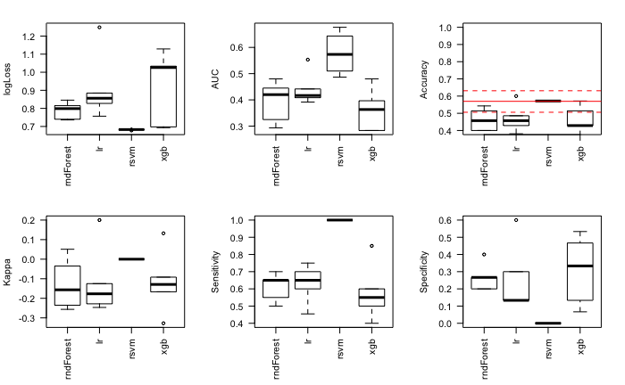

```r
ldata = aparcLobar_data
root_fname = '~/data/baseline_prediction/results/structLobarAparc_NVvsADHD'
save(ldata, groups, file=sprintf('%s.RData', root_fname), compress=T)
# ... waiting ...
res = collect_results(root_fname)
mylist = res[[1]]
run_models = res[[2]]
source('~/ncr_notebooks/baseline_prediction/src/do_metrics_plots.R')
```